# 3 Виконання

## 3.1 Завантаження даних

### Імпортуємо модулі pandas, numpy, matplotlib.pyplot, seaborn. Завантажимо датафрейм та виведемо інформацію про нього. Видалимо колонку "Unnamed: 0" та "case", що позначає індекси, оскільки вони вже були автоматично створені.

```python
import pandas as pd
import numpy as np
import matplotlib.pyplot as plt
import seaborn as sns
df = pd.read_csv('data/possum.csv')
df.drop(['Unnamed: 0', 'case'], axis=1, inplace=True)
df
```

|  | site | Pop | sex | age | hdlngth | skullw | totlngth | taill | footlgth | earconch | eye | chest | belly |
| --- | --- | --- | --- | --- | --- | --- | --- | --- | --- | --- | --- | --- | --- |
| 0 | 1 | Vic | m | 8.0 | 94.1 | 60.4 | 89.0 | 36.0 | 74.5 | 54.5 | 15.2 | 28.0 | 36.0 |
| 1 | 1 | Vic | f | 6.0 | 92.5 | 57.6 | 91.5 | 36.5 | 72.5 | 51.2 | 16.0 | 28.5 | 33.0 |
| 2 | 1 | Vic | f | 6.0 | 94.0 | 60.0 | 95.5 | 39.0 | 75.4 | 51.9 | 15.5 | 30.0 | 34.0 |
| 3 | 1 | Vic | f | 6.0 | 93.2 | 57.1 | 92.0 | 38.0 | 76.1 | 52.2 | 15.2 | 28.0 | 34.0 |
| 4 | 1 | Vic | f | 2.0 | 91.5 | 56.3 | 85.5 | 36.0 | 71.0 | 53.2 | 15.1 | 28.5 | 33.0 |
| ... | ... | ... | ... | ... | ... | ... | ... | ... | ... | ... | ... | ... | ... |
| 96 | 7 | other | m | 1.0 | 89.5 | 56.0 | 81.5 | 36.5 | 66.0 | 46.8 | 14.8 | 23.0 | 27.0 |
| 97 | 7 | other | m | 1.0 | 88.6 | 54.7 | 82.5 | 39.0 | 64.4 | 48.0 | 14.0 | 25.0 | 33.0 |
| 98 | 7 | other | f | 6.0 | 92.4 | 55.0 | 89.0 | 38.0 | 63.5 | 45.4 | 13.0 | 25.0 | 30.0 |
| 99 | 7 | other | m | 4.0 | 91.5 | 55.2 | 82.5 | 36.5 | 62.9 | 45.9 | 15.4 | 25.0 | 29.0 |
| 100 | 7 | other | f | 3.0 | 93.6 | 59.9 | 89.0 | 40.0 | 67.6 | 46.0 | 14.8 | 28.5 | 33.5 |

101 rows × 13 columns

*Завантажений датафрейм*

## 3.2 Перетворення даних

### Перевіримо датасет на наявність пустих значень. Як побачимо, пустих значень нема.

```python
df.isna().any()
```

```
site        False
Pop         False
sex         False
age         False
hdlngth     False
skullw      False
totlngth    False
taill       False
footlgth    False
earconch    False
eye         False
chest       False
belly       False
dtype: bool
```

*Перевірка на присутність пустих значень*

### Перетворимо категоріальні змінні у числові за допомогою класу LabelEncoder з модуля sklearn.preprocessing.

```python
from sklearn.preprocessing import LabelEncoder
df.Pop = LabelEncoder().fit_transform(df.Pop)
df.sex = LabelEncoder().fit_transform(df.sex)
df
```

|  | site | Pop | sex | age | hdlngth | skullw | totlngth | taill | footlgth | earconch | eye | chest | belly |
| --- | --- | --- | --- | --- | --- | --- | --- | --- | --- | --- | --- | --- | --- |
| 0 | 1 | 0 | 1 | 8.0 | 94.1 | 60.4 | 89.0 | 36.0 | 74.5 | 54.5 | 15.2 | 28.0 | 36.0 |
| 1 | 1 | 0 | 0 | 6.0 | 92.5 | 57.6 | 91.5 | 36.5 | 72.5 | 51.2 | 16.0 | 28.5 | 33.0 |
| 2 | 1 | 0 | 0 | 6.0 | 94.0 | 60.0 | 95.5 | 39.0 | 75.4 | 51.9 | 15.5 | 30.0 | 34.0 |
| 3 | 1 | 0 | 0 | 6.0 | 93.2 | 57.1 | 92.0 | 38.0 | 76.1 | 52.2 | 15.2 | 28.0 | 34.0 |
| 4 | 1 | 0 | 0 | 2.0 | 91.5 | 56.3 | 85.5 | 36.0 | 71.0 | 53.2 | 15.1 | 28.5 | 33.0 |
| ... | ... | ... | ... | ... | ... | ... | ... | ... | ... | ... | ... | ... | ... |
| 96 | 7 | 1 | 1 | 1.0 | 89.5 | 56.0 | 81.5 | 36.5 | 66.0 | 46.8 | 14.8 | 23.0 | 27.0 |
| 97 | 7 | 1 | 1 | 1.0 | 88.6 | 54.7 | 82.5 | 39.0 | 64.4 | 48.0 | 14.0 | 25.0 | 33.0 |
| 98 | 7 | 1 | 0 | 6.0 | 92.4 | 55.0 | 89.0 | 38.0 | 63.5 | 45.4 | 13.0 | 25.0 | 30.0 |
| 99 | 7 | 1 | 1 | 4.0 | 91.5 | 55.2 | 82.5 | 36.5 | 62.9 | 45.9 | 15.4 | 25.0 | 29.0 |
| 100 | 7 | 1 | 0 | 3.0 | 93.6 | 59.9 | 89.0 | 40.0 | 67.6 | 46.0 | 14.8 | 28.5 | 33.5 |

101 rows × 13 columns

*Перетворення категоріальних змінних в числові*

### Виконаємо масштабування даних. Для цього імпортуємо з sklearn.preprocessing клас MinMaxScaler.

```python
from sklearn.preprocessing import MinMaxScaler
df.loc[:, 'age':] = MinMaxScaler().fit_transform(df.loc[:, 'age':])
df
```

|  | site | Pop | sex | age | hdlngth | skullw | totlngth | taill | footlgth | earconch | eye | chest | belly |
| --- | --- | --- | --- | --- | --- | --- | --- | --- | --- | --- | --- | --- | --- |
| 0 | 1 | 0 | 1 | 0.875 | 0.563107 | 0.559140 | 0.651163 | 0.363636 | 0.806818 | 0.885906 | 0.48 | 0.60 | 0.733333 |
| 1 | 1 | 0 | 0 | 0.625 | 0.485437 | 0.408602 | 0.767442 | 0.409091 | 0.693182 | 0.664430 | 0.64 | 0.65 | 0.533333 |
| 2 | 1 | 0 | 0 | 0.625 | 0.558252 | 0.537634 | 0.953488 | 0.636364 | 0.857955 | 0.711409 | 0.54 | 0.80 | 0.600000 |
| 3 | 1 | 0 | 0 | 0.625 | 0.519417 | 0.381720 | 0.790698 | 0.545455 | 0.897727 | 0.731544 | 0.48 | 0.60 | 0.600000 |
| 4 | 1 | 0 | 0 | 0.125 | 0.436893 | 0.338710 | 0.488372 | 0.363636 | 0.607955 | 0.798658 | 0.46 | 0.65 | 0.533333 |
| ... | ... | ... | ... | ... | ... | ... | ... | ... | ... | ... | ... | ... | ... |
| 96 | 7 | 1 | 1 | 0.000 | 0.339806 | 0.322581 | 0.302326 | 0.409091 | 0.323864 | 0.369128 | 0.40 | 0.10 | 0.133333 |
| 97 | 7 | 1 | 1 | 0.000 | 0.296117 | 0.252688 | 0.348837 | 0.636364 | 0.232955 | 0.449664 | 0.24 | 0.30 | 0.533333 |
| 98 | 7 | 1 | 0 | 0.625 | 0.480583 | 0.268817 | 0.651163 | 0.545455 | 0.181818 | 0.275168 | 0.04 | 0.30 | 0.333333 |
| 99 | 7 | 1 | 1 | 0.375 | 0.436893 | 0.279570 | 0.348837 | 0.409091 | 0.147727 | 0.308725 | 0.52 | 0.30 | 0.266667 |
| 100 | 7 | 1 | 0 | 0.250 | 0.538835 | 0.532258 | 0.651163 | 0.727273 | 0.414773 | 0.315436 | 0.40 | 0.65 | 0.566667 |

101 rows × 13 columns

*Масштабування даних*

### Переставимо колонку "sex" на перше місце.

```python
name = 'sex'
col = df.pop(name)
df.insert(0, name, col)
df
```

|  | sex | site | Pop | age | hdlngth | skullw | totlngth | taill | footlgth | earconch | eye | chest | belly |
| --- | --- | --- | --- | --- | --- | --- | --- | --- | --- | --- | --- | --- | --- |
| 0 | 1 | 1 | 0 | 0.875 | 0.563107 | 0.559140 | 0.651163 | 0.363636 | 0.806818 | 0.885906 | 0.48 | 0.60 | 0.733333 |
| 1 | 0 | 1 | 0 | 0.625 | 0.485437 | 0.408602 | 0.767442 | 0.409091 | 0.693182 | 0.664430 | 0.64 | 0.65 | 0.533333 |
| 2 | 0 | 1 | 0 | 0.625 | 0.558252 | 0.537634 | 0.953488 | 0.636364 | 0.857955 | 0.711409 | 0.54 | 0.80 | 0.600000 |
| 3 | 0 | 1 | 0 | 0.625 | 0.519417 | 0.381720 | 0.790698 | 0.545455 | 0.897727 | 0.731544 | 0.48 | 0.60 | 0.600000 |
| 4 | 0 | 1 | 0 | 0.125 | 0.436893 | 0.338710 | 0.488372 | 0.363636 | 0.607955 | 0.798658 | 0.46 | 0.65 | 0.533333 |
| ... | ... | ... | ... | ... | ... | ... | ... | ... | ... | ... | ... | ... | ... |
| 96 | 1 | 7 | 1 | 0.000 | 0.339806 | 0.322581 | 0.302326 | 0.409091 | 0.323864 | 0.369128 | 0.40 | 0.10 | 0.133333 |
| 97 | 1 | 7 | 1 | 0.000 | 0.296117 | 0.252688 | 0.348837 | 0.636364 | 0.232955 | 0.449664 | 0.24 | 0.30 | 0.533333 |
| 98 | 0 | 7 | 1 | 0.625 | 0.480583 | 0.268817 | 0.651163 | 0.545455 | 0.181818 | 0.275168 | 0.04 | 0.30 | 0.333333 |
| 99 | 1 | 7 | 1 | 0.375 | 0.436893 | 0.279570 | 0.348837 | 0.409091 | 0.147727 | 0.308725 | 0.52 | 0.30 | 0.266667 |
| 100 | 0 | 7 | 1 | 0.250 | 0.538835 | 0.532258 | 0.651163 | 0.727273 | 0.414773 | 0.315436 | 0.40 | 0.65 | 0.566667 |

101 rows × 13 columns

*Переміщення колонки*

### Розділимо дані на аргументи та значення.

```python
df_x, df_y =  df.iloc[:, 1:], df.iloc[:, 0]
```

*Розділення даних на аргументи та значення*

### Ділимо дані на тренувальні та тестові для подальшої роботи. Імпортуємо модуль sklearn.model_selection та застосуємо функцію train_test_split. Розділимо набір даних на 80% навчальних та 20% тестових.

```python
from sklearn.model_selection import train_test_split
x_train, x_test, y_train, y_test = train_test_split(
    df_x, df_y, test_size=0.2, train_size=0.8, random_state=11)
x_train.shape, x_test.shape
```

```
((80, 12), (21, 12))
```

*Поділ інформації на тренувальну та тестову*

## 3.3 KNN

### Було обрано чотири методи K-Nearest Neighbors, Logistic Regression, Random Forest, SVM.

### Зберігатимемо результати тестування моделей у списку results.

```python
results = []
```

*Список результатів*

### Для виконання роботи методу KNN імпортуємо sklearn.neighbors.KNeighborsClassifier та sklearn.model_selection.GridSearchCV.

```python
from sklearn.neighbors import KNeighborsClassifier
from sklearn.model_selection import GridSearchCV
```

*Імпортування модулів*

### Визначимо, які варіанти параметрів найкраще вирішують дану задачу.

```python
classificator = KNeighborsClassifier()
params = {'n_neighbors': range(1, 60)}
grid_search = GridSearchCV(classificator, params, cv=10, verbose=1)
grid_search.fit(x_train, y_train)
knn = grid_search.best_estimator_
knn
```

```
Fitting 10 folds for each of 59 candidates, totalling 590 fits
```

```
KNeighborsClassifier(n_neighbors=1)
```

*Визначення найкращого параметра*

### Натренуємо модель з найкращим параметром.

```python
knn.fit(x_train, y_train)
```

```
KNeighborsClassifier(n_neighbors=1)
```

*Тренування моделі K-Nearest Neighbors*

### Визначимо точність моделі на тренувальних та тестових даних.

```python
train_score = round(knn.score(x_train, y_train), 5)
test_score = round(knn.score(x_test, y_test), 5)
results.append({'method': 'knn', 'score': train_score, 'type': 'train'})
results.append({'method': 'knn', 'score': test_score, 'type': 'test'})
print(f'Train accuracy: {train_score}')
print(f'Test accuracy: {test_score}')
```

```
Train accuracy: 1.0
Test accuracy: 0.47619
```

*Точність моделі K-Nearest Neighbors*

```python
from sklearn.metrics import confusion_matrix
def conf_mat(model, x_test, y_test):
    y_predicted = model.predict(x_test)
    cm = confusion_matrix(y_test, y_predicted)
    plt.figure(figsize = (8,5))
    sns.heatmap(cm, annot=True, fmt=".1f")
    plt.xlabel('Predicted')
```

*Функція побудови матриці невідповідностей*

### Матриця має два рядки та дві колонки: перший ряд і перша колонка - це істинно позитивні значення: опосум має стать A, і модель визначила цю стать. Перший ряд і друга колонка - хибно позитивні, тобто опосум має стать A, але модель вказала на стать B; другий ряд і перша колонка - хибно негативні, тобто опосум має стать B, але модель вказала на стать A; другий ряд і друга колонка - істинно негативні, тобто опосум має стать B, і модель вказала на стать B.

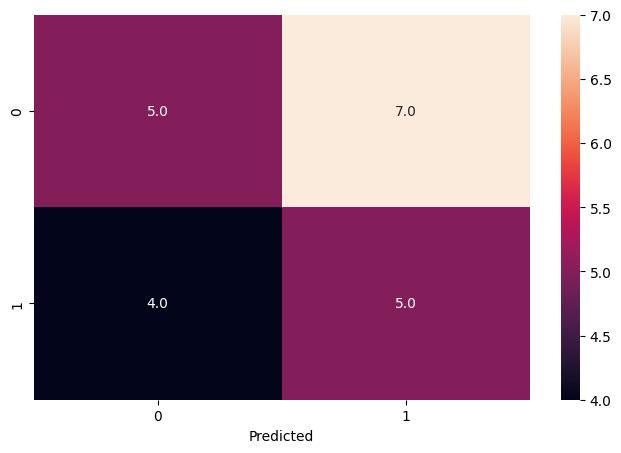

```python
conf_mat(knn, x_test, y_test)
```

*Матриця невідповідностей для K-Nearest Neighbors*

### Побудуємо графік ROC( Receiver Operating Characteristic ), що є графіком істинно позитивної відносної частоти проти хибно позитивної частоти. Це показує компроміс між чутливістю та специфічністю. Для цього імпортуємо sklearn.metrics.roc_curve та sklearn.metrics.roc_auc_score. До того ж визначимо AUC( Area Under the ROC Curve ), що є мірою того, наскільки добре модель може розрізняти позитивні та негативні результати. Він коливається від 0 до 1, де 1 є найкращим класифікатором, а 0,5 – випадковим класифікатором. AUC корисний під час порівняння продуктивності різних класифікаторів на одному наборі даних, бо дає єдине число, яке підсумовує загальну продуктивність.

```python
from sklearn.metrics import roc_curve, roc_auc_score
def roc(model, x_test, y_test):
    y_pred_proba = model.predict_proba(x_test)[::,1]
    fpr, tpr, _ = roc_curve(y_test,  y_pred_proba)
    auc = roc_auc_score(y_test, y_pred_proba)
    plt.plot(fpr,tpr,label="Area = "+str(auc)+')')
    plt.plot([0, 1], [0, 1],'r--')
    plt.xlim([0.0, 1.0])
    plt.ylim([0.0, 1.05])
    plt.xlabel('False Positive Rate')
    plt.ylabel('True Positive Rate')
    plt.title('Receiver operating characteristic')
    plt.legend(loc=4)
    plt.show()
```

*Імпортування модуля та визначення функції roc*

### Побудуємо ROC для K-Nearest Neighbors.

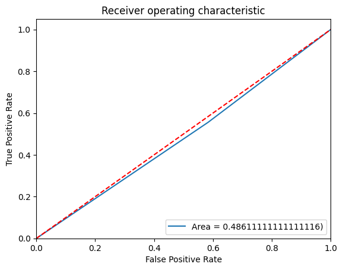

```python
roc(knn, x_test, y_test)
```

*Графік ROC для K-Nearest Neighbors*

## 3.4 Logistic Regression

### Для виконання роботи методу Logistic Regression імпортуємо sklearn.linear_model.LogisticRegression. Визначимо найкращі параметри моделі, передавши в неї параметри регуляризації.

```python
from sklearn.linear_model import LogisticRegression
logisticRegr = LogisticRegression()
c = np.logspace(-4, 4, 60)
penalty = ['l1', 'l2']
params = dict(C=c, penalty=penalty)
log_reg = GridSearchCV(logisticRegr, params, cv=10, verbose=1)
log_reg.fit(x_train, y_train)
```

```
Fitting 10 folds for each of 120 candidates, totalling 1200 fits
```

[output not shown]

[output cut: 728 more lines]

[output not shown]

```
GridSearchCV(cv=10, estimator=LogisticRegression(),
             param_grid={'C': array([1.00000000e-04, 1.36644835e-04, 1.86718109e-04, 2.55140652e-04,
       3.48636523e-04, 4.76393801e-04, 6.50967523e-04, 8.89513497e-04,
       1.21547425e-03, 1.66088278e-03, 2.26951054e-03, 3.10116893e-03,
       4.23758716e-03, 5.79044398e-03, 7.91234262e-03, 1.08118075e-02,
       1.47737765e-02, 2.01876025e-02, 2.75853...
       7.60949669e+00, 1.03979842e+01, 1.42083083e+01, 1.94149195e+01,
       2.65294846e+01, 3.62511705e+01, 4.95353521e+01, 6.76875001e+01,
       9.24914728e+01, 1.26384820e+02, 1.72698329e+02, 2.35983347e+02,
       3.22459055e+02, 4.40623643e+02, 6.02089449e+02, 8.22724134e+02,
       1.12421004e+03, 1.53617495e+03, 2.09910372e+03, 2.86831681e+03,
       3.91940677e+03, 5.35566692e+03, 7.31824222e+03, 1.00000000e+04]),
                         'penalty': ['l1', 'l2']},
             verbose=1)
```

*Тренування моделі Logistic Regression*

### Визначимо точність моделі на тренувальних та тестових даних.

```python
train_score = round(log_reg.score(x_train, y_train), 5)
test_score = round(log_reg.score(x_test, y_test), 5)
results.append({'method': 'logress', 'score': train_score, 'type': 'train'})
results.append({'method': 'logress', 'score': test_score, 'type': 'test'})
print(f'Train accuracy: {train_score}')
print(f'Test accuracy: {test_score}')
```

```
Train accuracy: 0.775
Test accuracy: 0.42857
```

*Точність моделі Logistic Regression*

### Визначимо продуктивність роботи моделі на прикладі матриці невідповідностей.

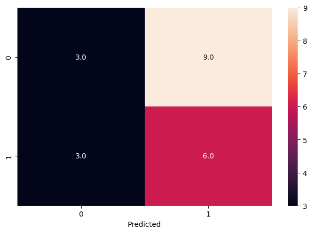

```python
conf_mat(log_reg, x_test, y_test)
```

*Матриця невідповідностей для Logistic Regression*

### Побудуємо графік ROC для Logistic Regression.

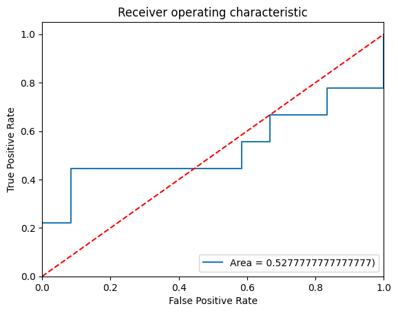

```python
roc(log_reg, x_test, y_test)
```

*Графік ROC для Logistic Regression*

## 3.5 Random Forest

```python
from sklearn.ensemble import RandomForestClassifier
# Кількість дерев
n_estimators = [int(x) for x in np.linspace(start = 10, stop = 300, num = 60)]
params = {'n_estimators': n_estimators}
rf = RandomForestClassifier()
rf_random = GridSearchCV(rf, param_grid=params, cv=3, n_jobs=5)
rf_random.fit(x_train, y_train)
```

```
GridSearchCV(cv=3, estimator=RandomForestClassifier(), n_jobs=5,
             param_grid={'n_estimators': [10, 14, 19, 24, 29, 34, 39, 44, 49,
                                          54, 59, 64, 68, 73, 78, 83, 88, 93,
                                          98, 103, 108, 113, 118, 123, 127, 132,
                                          137, 142, 147, 152, ...]})
```

*Тренування моделі Random Forest*

### Визначимо точність моделі на тренувальних та тестових даних.

```python
train_score = round(rf_random.score(x_train, y_train), 5)
test_score = round(rf_random.score(x_test, y_test), 5)
results.append({'method': 'rf', 'score': train_score, 'type': 'train'})
results.append({'method': 'rf', 'score': test_score, 'type': 'test'})
print(f'Train accuracy: {train_score}')
print(f'Test accuracy: {test_score}')
```

```
Train accuracy: 1.0
Test accuracy: 0.33333
```

*Точність моделі Random Forest*

### Визначимо продуктивність роботи моделі на прикладі матриці невідповідностей.

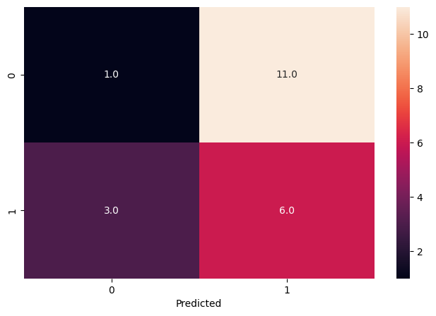

```python
conf_mat(rf_random, x_test, y_test)
```

*Матриця невідповідностей для Random Forest*

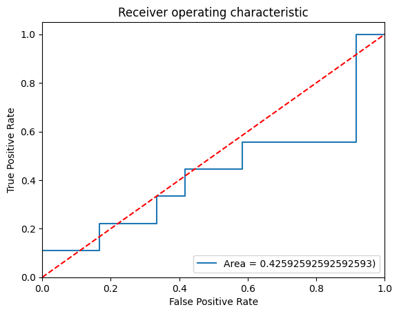

```python
roc(rf_random, x_test, y_test)
```

*Графік ROC для Random Forest*

## 3.6 SVM

### Для виконання роботи методу SVM імпортуємо sklearn.svm.SVC.

```python
from sklearn.svm import SVC
c = [1, 5]
params = {'C': c, 'kernel': ['rbf', 'linear']}
svc = SVC(gamma='auto', probability=True)
svc_model = GridSearchCV(svc, param_grid=params, cv=3, n_jobs=5)
svc_model.fit(x_train, y_train)
```

```
GridSearchCV(cv=3, estimator=SVC(gamma='auto', probability=True), n_jobs=5,
             param_grid={'C': [1, 5], 'kernel': ['rbf', 'linear']})
```

*Тренування моделі SVM*

### Визначимо точність моделі на тренувальних та тестових даних.

```python
train_score = round(svc_model.score(x_train, y_train), 5)
test_score = round(svc_model.score(x_test, y_test), 5)
results.append({'method': 'svm', 'score': train_score, 'type': 'train'})
results.append({'method': 'svm', 'score': test_score, 'type': 'test'})
print(f'Train accuracy: {train_score}')
print(f'Test accuracy: {test_score}')
```

```
Train accuracy: 0.8125
Test accuracy: 0.47619
```

*Точність моделі SVM*

### Визначимо продуктивність роботи моделі на прикладі матриці невідповідностей.

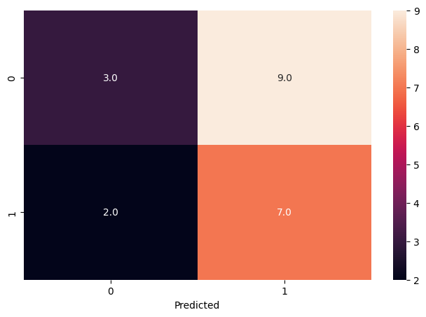

```python
conf_mat(svc_model, x_test, y_test)
```

*Матриця невідповідностей для SVM*

### Побудуємо графік ROC для SVM.

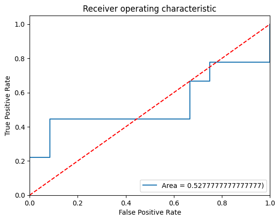

```python
roc(svc_model, x_test, y_test)
```

*Графік ROC для SVM*

## 3.7 Порівняння результатів

### Проаналізувавши окремо кожен із методів, проведемо порівняння даних методів.

```python
df_score = pd.DataFrame(results, columns=['method','score','type'])
df_score
```

|  | method | score | type |
| --- | --- | --- | --- |
| 0 | knn | 1.00000 | train |
| 1 | knn | 0.47619 | test |
| 2 | logress | 0.77500 | train |
| 3 | logress | 0.42857 | test |
| 4 | rf | 1.00000 | train |
| 5 | rf | 0.33333 | test |
| 6 | svm | 0.81250 | train |
| 7 | svm | 0.47619 | test |

*Датафрейм результатів*

### Для наочності побудуємо гістограму.

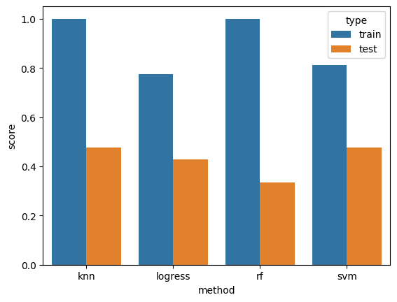

```python
sns.barplot(x='method', y='score', hue='type', data=df_score)
```

*Результати моделей*

### Як бачимо, усіма методами отримали доволі низьку точність. Найкраще себе показали KNN та SVM. Найгірше - Random Forest. Такі результати пояснюються тим, що а датасеті надзвичайно мало тренувальних даних, і їхню кількість треба суттєво збільшувати для досягнення вищих показників точності.